# Увод в иконометрията

## Упражнение 1 (03.10.2023)

### Задача 1

Хвърляме правилна монета 3 пъти. Намерете разпределението на сл.в. X, брой паднали се гербове. Намерете очакването и дисперсията на X.

```r
x <- 0:3
prob <- c(1/8, 3/8 , 3/8, 1/8)

mu <- sum(x * prob)
sigma2 <- sum((x - mu)^2 * prob)

print(mu)
```

```
## [1] 1.5
```

```r
print(sigma2)
```

```
## [1] 0.75
```

```r
# cumulative distribution function
F <- cumsum(prob)
print(F)
```

```
## [1] 0.125 0.500 0.875 1.000
```

### Биномно разпределение

```r
# dbinom -> P(X = x), X in Bi(size, prob)
print(dbinom(x=2, size=10, prob=1/3))
```

```
## [1] 0.1950922
```

```r
# pbinom -> P(X <= q), X in Bi(size, prob)
print(pbinom(q=2, size=3, prob=1/2))
```

```
## [1] 0.875
```

```r
# pbinom -> 1 - P(X <= q), X in Bi(size, prob)
print(pbinom(q=2, size=3, prob=1/2, lower.tail=F))
```

```
## [1] 0.125
```

```r
# qbinom -> pbinom^(-1)
print(qbinom(p=0.875, size=3, prob=1/2))
```

```
## [1] 2
```

```r
# rbinom -> sample Bi(size, prob)
print(rbinom(n=5, size=10, prob=1/2))
```

```
## [1] 3 5 4 7 3
```

### Задача 2

Малка фабрика произвежда крушки, които биват тествани преди опаковането и доставката. Служителите не могат да тестват всички крушки и затова проверяват една на сто произведени за час. Установили, че в произведените за един час има 2% неработещи, но въпреки това изпратили крушките за продажба. Като продавач се притеснявате за качеството на тези крушки, които продавате по една. Ако клиент си купи 20 крушки, каква е вероятността, че всичките ще работят?

```r
# X in Bi(20, 0.98)
print(dbinom(x=20, size=20, prob=0.98))
```

```
## [1] 0.667608
```

```r
mean <- 20 * 0.98
print(mean)
```

```
## [1] 19.6
```

```r
x <- c(0:20)
prob <- dbinom(x=x, size=20, prob=0.98)
print(prob)
```

```
##  [1] 1.048576e-34 1.027604e-31 4.783499e-29 1.406349e-26 2.928721e-24
##  [6] 4.592235e-22 5.625487e-20 5.512978e-18 4.389709e-16 2.867943e-14
## [11] 1.545821e-12 6.885931e-11 2.530580e-09 7.630671e-08 1.869514e-06
## [16] 3.664248e-05 5.610880e-04 6.469015e-03 5.283029e-02 2.724930e-01
## [21] 6.676080e-01
```

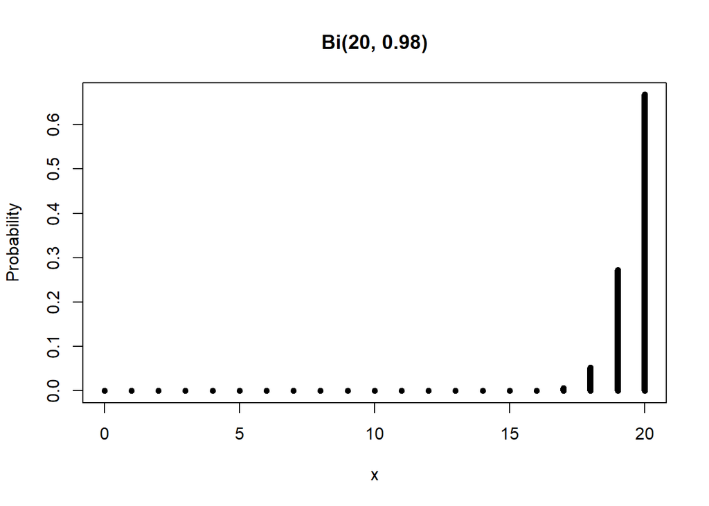

```r
plot(x=x,
     y=prob,
     type='h',
     lwd=6,
     ylab='Probability',
     main='Bi(20, 0.98)'
)
```

## Упражнение 2 (10.10.2023)

```r
library(distr) # for the 'AbscontDistribution' function
library(distrEx) # for E(X) and var(X)
library(readxl) # for read_excel
library(BSDA) # for z.test()
```

### Задача 1

Let X have PDF f(x) = 3x^2, 0 < x < 1 and find P(0.14 < X < 0.71)

```r
f <- function(x) {
  3 * x^2
}
```

```r
integrate(f, lower=0.14, upper=0.71)
```

```
## 0.355167 with absolute error < 3.9e-15
```

```r
X <- AbscontDistribution(d=f, low1=0, up1=1)
```

```r
E(X); var(X)
```

```
## [1] 0.7496337
```

```
## [1] 0.03768305
```

### Задача 2

Suppose in a mathematics quiz there are 30 participants. A question is given to all 30 participants, and the time allowed to answer it is 25 seconds. Find the probability of a random participant responding within 6 seconds?

```r
punif(6, min=0, max=25)
```

```
## [1] 0.24
```

### Задача 3

Suppose a fight is about to land and the announcement says that the expected time for the plane to will definitely land is in the next 30 minutes. What is the average time before the fight lands? Find the probability of getting the fight landing between 25 and 30 minutes and between 10 and 20 minutes using R.

```r
qunif(0.5, min=0, max=30)
```

```
## [1] 15
```

```r
punif(30, 0, 30) - punif(25, 0, 30); punif(25, 0, 30, lower.tail=FALSE)
```

```
## [1] 0.1666667
```

```
## [1] 0.1666667
```

```r
punif(20, 0, 30) - punif(10, 0, 30)
```

```
## [1] 0.3333333
```

### Задача 4

Assume we have a uniform distribution with density f(x) = 1/23, 0 <= x <= 23, X is U(0, 23). Determine the 90th percentile and generate 3 random numbers from the distribution.

```r
qunif(0.9, 0, 23)
```

```
## [1] 20.7
```

```r
runif(3, 0, 23)
```

```
## [1] 15.936105 17.410497  2.650156
```

### Задача 5

```r
pnorm(9, mean=10, sd=2)
```

```
## [1] 0.3085375
```

```r
pnorm(11, mean=10, sd=2, lower.tail=FALSE)
```

```
## [1] 0.3085375
```

```r
pnorm(11, 10, 2) - pnorm(9, 10, 2)
```

```
## [1] 0.3829249
```

```r
qnorm(0.9, 10, 2); qnorm(0.9, 10, 2)
```

```
## [1] 12.5631
```

```
## [1] 12.5631
```

```r
pnorm(12, 10, 2) - pnorm(8, 10, 2)
```

```
## [1] 0.6826895
```

```r
pnorm(14, 10, 2) - pnorm(6, 10, 2)
```

```
## [1] 0.9544997
```

```r
pnorm(16, 10, 2) - pnorm(4, 10, 2)
```

```
## [1] 0.9973002
```

### Задача 6

A toy manufacturer undertakes regular assessment of employee performance. This performance testing consists of measuring the number of a toys that employees can make per hour, with the historical data recording a rate of 85$ per hour with a standard deviation of 15 units. All new employees are tested after a period of training. A new employee is tested on 45 separate random occasions and found to have an output given in the data file *toy_manufacturer.xlsx*. Does this indicate that the new employee’s output is significantly different from the average output? Test at the 5% significance level.

```r
toys <- read_xlsx('data/toy_manufacturer.xlsx')
toys
```

| ID | Sample data |
| --- | --- |
| 1 | 88.6 |
| 2 | 63.8 |
| 3 | 95.6 |
| 4 | 94.4 |
| 5 | 118.2 |
| 6 | 84.4 |
| 7 | 81.6 |
| 8 | 78.6 |
| 9 | 56.6 |
| 10 | 77.8 |

[output cut: 35 more lines]

```r
bar_X <- mean(toys$`Sample data`)
bar_X
```

```
## [1] 88.74
```

```r
sigma <- 15
n <- length(toys$`Sample data`)
mu_0 <- 85

z <- (bar_X - mu_0) / (sigma/sqrt(n))
z
```

```
## [1] 1.672579
```

```r
p_value <- 2 * (1 - pnorm(1.67))
p_value
```

```
## [1] 0.09491936
```

```r
z.test(toys$`Sample data`, mu=85, sigma.x=15, conf.level=0.95)
```

```
##
##  One-sample z-Test
##
## data:  toys$`Sample data`
## z = 1.6726, p-value = 0.09441
## alternative hypothesis: true mean is not equal to 85
## 95 percent confidence interval:
##  84.35739 93.12261
## sample estimates:
## mean of x
##     88.74
```

We fail to reject the null hypothesis.

## Упражнение 3 (17.10.2023)

```r
wine_df <- read.csv('data/wine.csv')
wine_df
```

| Year | Price | WinterRain | AGST | HarvestRain | Age | FrancePop |
| --- | --- | --- | --- | --- | --- | --- |
| 1952 | 7.4950 | 600 | 17.1167 | 160 | 31 | 43183.57 |
| 1953 | 8.0393 | 690 | 16.7333 | 80 | 30 | 43495.03 |
| 1955 | 7.6858 | 502 | 17.1500 | 130 | 28 | 44217.86 |
| 1957 | 6.9845 | 420 | 16.1333 | 110 | 26 | 45152.25 |
| 1958 | 6.7772 | 582 | 16.4167 | 187 | 25 | 45653.81 |
| 1959 | 8.0757 | 485 | 17.4833 | 187 | 24 | 46128.64 |
| 1960 | 6.5188 | 763 | 16.4167 | 290 | 23 | 46584.00 |
| 1961 | 8.4937 | 830 | 17.3333 | 38 | 22 | 47128.00 |
| 1962 | 7.3880 | 697 | 16.3000 | 52 | 21 | 48088.67 |
| 1963 | 6.7127 | 608 | 15.7167 | 155 | 20 | 48798.99 |

[output cut: 15 more lines]

```r
summary(wine_df)
```

```
##       Year          Price         WinterRain         AGST        HarvestRain
##  Min.   :1952   Min.   :6.205   Min.   :376.0   Min.   :14.98   Min.   : 38.0
##  1st Qu.:1960   1st Qu.:6.519   1st Qu.:536.0   1st Qu.:16.20   1st Qu.: 89.0
##  Median :1966   Median :7.121   Median :600.0   Median :16.53   Median :130.0
##  Mean   :1966   Mean   :7.067   Mean   :605.3   Mean   :16.51   Mean   :148.6
##  3rd Qu.:1972   3rd Qu.:7.495   3rd Qu.:697.0   3rd Qu.:17.07   3rd Qu.:187.0
##  Max.   :1978   Max.   :8.494   Max.   :830.0   Max.   :17.65   Max.   :292.0
##       Age         FrancePop
##  Min.   : 5.0   Min.   :43184
##  1st Qu.:11.0   1st Qu.:46584
##  Median :17.0   Median :50255
##  Mean   :17.2   Mean   :49694
##  3rd Qu.:23.0   3rd Qu.:52894
##  Max.   :31.0   Max.   :54602
```

```r
model1 <- lm(Price ~ AGST, data=wine_df)
summary(model1)
```

```
##
## Call:
## lm(formula = Price ~ AGST, data = wine_df)
##
## Residuals:
##      Min       1Q   Median       3Q      Max
## -0.78450 -0.23882 -0.03727  0.38992  0.90318
##
## Coefficients:
##             Estimate Std. Error t value Pr(>|t|)
## (Intercept)  -3.4178     2.4935  -1.371 0.183710
## AGST          0.6351     0.1509   4.208 0.000335 ***
## ---
## Signif. codes:  0 '***' 0.001 '**' 0.01 '*' 0.05 '.' 0.1 ' ' 1
##
## Residual standard error: 0.4993 on 23 degrees of freedom
## Multiple R-squared:  0.435,  Adjusted R-squared:  0.4105
## F-statistic: 17.71 on 1 and 23 DF,  p-value: 0.000335
```

$$t-value = \frac{Estimate}{Std. Error}.
Искаме \ да \ е \ (относително) \ голяма \ стойност.$$

$$Pr(>|t|): p-value \ при \ тестване \
коефициентите \ \beta_i \ \ срещу \ H_0: \beta_i = 0. \ Искаме \ да \ е
\ малка \ стойност.$$
$$Adjusted \
R^2: проверяваме \ дали \ не \ сме \ включили \ прекалено \ много \
променливи.$$

```r
model2 <- lm(Price ~ .-Year, data=wine_df)
summary(model2)
```

```
##
## Call:
## lm(formula = Price ~ . - Year, data = wine_df)
##
## Residuals:
##      Min       1Q   Median       3Q      Max
## -0.48179 -0.24662 -0.00726  0.22012  0.51987
##
## Coefficients:
##               Estimate Std. Error t value Pr(>|t|)
## (Intercept) -4.504e-01  1.019e+01  -0.044 0.965202
## WinterRain   1.043e-03  5.310e-04   1.963 0.064416 .
## AGST         6.012e-01  1.030e-01   5.836 1.27e-05 ***
## HarvestRain -3.958e-03  8.751e-04  -4.523 0.000233 ***
## Age          5.847e-04  7.900e-02   0.007 0.994172
## FrancePop   -4.953e-05  1.667e-04  -0.297 0.769578
## ---
## Signif. codes:  0 '***' 0.001 '**' 0.01 '*' 0.05 '.' 0.1 ' ' 1
##
## Residual standard error: 0.3019 on 19 degrees of freedom
## Multiple R-squared:  0.8294, Adjusted R-squared:  0.7845
## F-statistic: 18.47 on 5 and 19 DF,  p-value: 1.044e-06
```

```r
model1$residuals
```

```
##           1           2           3           4           5           6
##  0.04204258  0.82983774  0.21169394  0.15609432 -0.23119140  0.38991701
##           7           8           9          10          11          12
## -0.48959140  0.90318115  0.45372410  0.14887461 -0.23882157 -0.08974238
##          13          14          15          16          17          18
##  0.66185660 -0.05211511 -0.62726647 -0.74714947  0.42113502 -0.03727441
##          19          20          21          22          23          24
##  0.10685278 -0.78450270 -0.64017590 -0.05508720 -0.67055321 -0.22040381
##          25
##  0.55866518
```

```r
SSE_model1 <- sum(model1$residuals^2)
SSE_model1
```

```
## [1] 5.734875
```

```r
SSE_model2 <- sum(model2$residuals^2)
SSE_model2
```

```
## [1] 1.732113
```

**Проверка за мултиколинеарност между Age и FrancePop**

(линейна зависимост между две “независими” променливи)

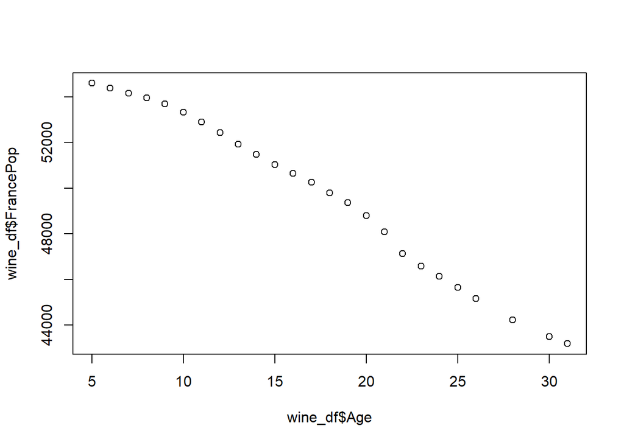

```r
plot(wine_df$Age, wine_df$FrancePop)
```

```r
cor(wine_df$Age, wine_df$FrancePop)
```

```
## [1] -0.9944851
```

```r
cor(wine_df)
```

```
##                    Year      Price   WinterRain        AGST HarvestRain
## Year         1.00000000 -0.4477679  0.016970024 -0.24691585  0.02800907
## Price       -0.44776786  1.0000000  0.136650547  0.65956286 -0.56332190
## WinterRain   0.01697002  0.1366505  1.000000000 -0.32109061 -0.27544085
## AGST        -0.24691585  0.6595629 -0.321090611  1.00000000 -0.06449593
## HarvestRain  0.02800907 -0.5633219 -0.275440854 -0.06449593  1.00000000
## Age         -1.00000000  0.4477679 -0.016970024  0.24691585 -0.02800907
## FrancePop    0.99448510 -0.4668616 -0.001621627 -0.25916227  0.04126439
##                     Age    FrancePop
## Year        -1.00000000  0.994485097
## Price        0.44776786 -0.466861641
## WinterRain  -0.01697002 -0.001621627
## AGST         0.24691585 -0.259162274
## HarvestRain -0.02800907  0.041264394
## Age          1.00000000 -0.994485097
## FrancePop   -0.99448510  1.000000000
```

```r
model3 <- lm(Price ~ AGST + HarvestRain + Age, data=wine_df)
summary(model3)
```

```
##
## Call:
## lm(formula = Price ~ AGST + HarvestRain + Age, data = wine_df)
##
## Residuals:
##      Min       1Q   Median       3Q      Max
## -0.66258 -0.22953 -0.00268  0.27236  0.49391
##
## Coefficients:
##               Estimate Std. Error t value Pr(>|t|)
## (Intercept) -1.4778196  1.6274142  -0.908  0.37414
## AGST         0.5322922  0.0995343   5.348 2.65e-05 ***
## HarvestRain -0.0045386  0.0008757  -5.183 3.90e-05 ***
## Age          0.0250875  0.0087249   2.875  0.00905 **
## ---
## Signif. codes:  0 '***' 0.001 '**' 0.01 '*' 0.05 '.' 0.1 ' ' 1
##
## Residual standard error: 0.3186 on 21 degrees of freedom
## Multiple R-squared:   0.79,  Adjusted R-squared:   0.76
## F-statistic: 26.34 on 3 and 21 DF,  p-value: 2.596e-07
```

```r
model4 <- lm(Price ~ AGST + HarvestRain + Age + WinterRain, data=wine_df)
summary(model4)
```

```
##
## Call:
## lm(formula = Price ~ AGST + HarvestRain + Age + WinterRain, data = wine_df)
##
## Residuals:
##      Min       1Q   Median       3Q      Max
## -0.45470 -0.24273  0.00752  0.19773  0.53637
##
## Coefficients:
##               Estimate Std. Error t value Pr(>|t|)
## (Intercept) -3.4299802  1.7658975  -1.942 0.066311 .
## AGST         0.6072093  0.0987022   6.152  5.2e-06 ***
## HarvestRain -0.0039715  0.0008538  -4.652 0.000154 ***
## Age          0.0239308  0.0080969   2.956 0.007819 **
## WinterRain   0.0010755  0.0005073   2.120 0.046694 *
## ---
## Signif. codes:  0 '***' 0.001 '**' 0.01 '*' 0.05 '.' 0.1 ' ' 1
##
## Residual standard error: 0.295 on 20 degrees of freedom
## Multiple R-squared:  0.8286, Adjusted R-squared:  0.7943
## F-statistic: 24.17 on 4 and 20 DF,  p-value: 2.036e-07
```

```r
SSE_model4 <- sum(model4$residuals^2)
SSE_model4
```

```
## [1] 1.740162
```

```r
wine_test_df <- read.csv('data/wine_test.csv')
wine_test_df
```

| Year | Price | WinterRain | AGST | HarvestRain | Age | FrancePop |
| --- | --- | --- | --- | --- | --- | --- |
| 1979 | 6.9541 | 717 | 16.1667 | 122 | 4 | 54835.83 |
| 1980 | 6.4979 | 578 | 16.0000 | 74 | 3 | 55110.24 |

```r
predict_test <- predict(model4, newdata=wine_test_df)
predict_test
```

```
##        1        2
## 6.768925 6.684910
```

```r
SSE_sample <- sum((predict_test - wine_test_df$Price)^2)
SSE_sample
```

```
## [1] 0.06926281
```

```r
SST_sample <- sum((mean(wine_df$Price) - wine_test_df$Price)^2)
SST_sample
```

```
## [1] 0.3369269
```

```r
R2_sample <- 1 - (SSE_sample/SST_sample)
R2_sample
```

```
## [1] 0.7944278
```

$$Out-of-sample \ R^2 \ може \ да \ приема
\ отрицателни \ стойности!$$

## Упражнение 4 (24.10.2023)

### Moneyball

```r
baseball <- read.csv('data/baseball.csv')
baseball
```

| Team | League | Year | RS | RA | W | OBP | SLG | BA | Playoffs | RankSeason | RankPlayoffs | G | OOBP | OSLG |
| --- | --- | --- | --- | --- | --- | --- | --- | --- | --- | --- | --- | --- | --- | --- |
| ARI | NL | 2012 | 734 | 688 | 81 | 0.328 | 0.418 | 0.259 | 0 | NA | NA | 162 | 0.317 | 0.415 |
| ATL | NL | 2012 | 700 | 600 | 94 | 0.320 | 0.389 | 0.247 | 1 | 4 | 5 | 162 | 0.306 | 0.378 |
| BAL | AL | 2012 | 712 | 705 | 93 | 0.311 | 0.417 | 0.247 | 1 | 5 | 4 | 162 | 0.315 | 0.403 |
| BOS | AL | 2012 | 734 | 806 | 69 | 0.315 | 0.415 | 0.260 | 0 | NA | NA | 162 | 0.331 | 0.428 |
| CHC | NL | 2012 | 613 | 759 | 61 | 0.302 | 0.378 | 0.240 | 0 | NA | NA | 162 | 0.335 | 0.424 |
| CHW | AL | 2012 | 748 | 676 | 85 | 0.318 | 0.422 | 0.255 | 0 | NA | NA | 162 | 0.319 | 0.405 |
| CIN | NL | 2012 | 669 | 588 | 97 | 0.315 | 0.411 | 0.251 | 1 | 2 | 4 | 162 | 0.305 | 0.390 |
| CLE | AL | 2012 | 667 | 845 | 68 | 0.324 | 0.381 | 0.251 | 0 | NA | NA | 162 | 0.336 | 0.430 |
| COL | NL | 2012 | 758 | 890 | 64 | 0.330 | 0.436 | 0.274 | 0 | NA | NA | 162 | 0.357 | 0.470 |
| DET | AL | 2012 | 726 | 670 | 88 | 0.335 | 0.422 | 0.268 | 1 | 6 | 2 | 162 | 0.314 | 0.402 |

[output cut: 1222 more lines]

```r
moneyball <- subset(baseball, Year < 2002)
moneyball
```

|  | Team | League | Year | RS | RA | W | OBP | SLG | BA | Playoffs | RankSeason | RankPlayoffs | G | OOBP | OSLG |
| --- | --- | --- | --- | --- | --- | --- | --- | --- | --- | --- | --- | --- | --- | --- | --- |
| 331 | ANA | AL | 2001 | 691 | 730 | 75 | 0.327 | 0.405 | 0.261 | 0 | NA | NA | 162 | 0.331 | 0.412 |
| 332 | ARI | NL | 2001 | 818 | 677 | 92 | 0.341 | 0.442 | 0.267 | 1 | 5 | 1 | 162 | 0.311 | 0.404 |
| 333 | ATL | NL | 2001 | 729 | 643 | 88 | 0.324 | 0.412 | 0.260 | 1 | 7 | 3 | 162 | 0.314 | 0.384 |
| 334 | BAL | AL | 2001 | 687 | 829 | 63 | 0.319 | 0.380 | 0.248 | 0 | NA | NA | 162 | 0.337 | 0.439 |
| 335 | BOS | AL | 2001 | 772 | 745 | 82 | 0.334 | 0.439 | 0.266 | 0 | NA | NA | 161 | 0.329 | 0.393 |
| 336 | CHC | NL | 2001 | 777 | 701 | 88 | 0.336 | 0.430 | 0.261 | 0 | NA | NA | 162 | 0.321 | 0.398 |
| 337 | CHW | AL | 2001 | 798 | 795 | 83 | 0.334 | 0.451 | 0.268 | 0 | NA | NA | 162 | 0.334 | 0.427 |
| 338 | CIN | NL | 2001 | 735 | 850 | 66 | 0.324 | 0.419 | 0.262 | 0 | NA | NA | 162 | 0.341 | 0.455 |
| 339 | CLE | AL | 2001 | 897 | 821 | 91 | 0.350 | 0.458 | 0.278 | 1 | 6 | 4 | 162 | 0.341 | 0.417 |
| 340 | COL | NL | 2001 | 923 | 906 | 73 | 0.354 | 0.483 | 0.292 | 0 | NA | NA | 162 | 0.350 | 0.480 |

[output cut: 892 more lines]

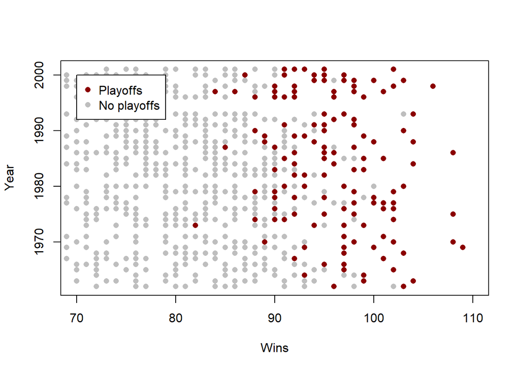

```r
plot(
  moneyball$W,
  moneyball$Year,
  xlim=c(70, 110),
  pch=16,
  xlab='Wins',
  ylab='Year',
  col=ifelse(moneyball$Playoffs==1, 'darkred', 'gray')
)

legend(
  70,
  2000,
  col=c('darkred', 'gray'),
  legend=c('Playoffs', 'No playoffs'),
  pch=16
)
```

```r
moneyball$RD <- moneyball$RS - moneyball$RA
moneyball
```

|  | Team | League | Year | RS | RA | W | OBP | SLG | BA | Playoffs | RankSeason | RankPlayoffs | G | OOBP | OSLG | RD |
| --- | --- | --- | --- | --- | --- | --- | --- | --- | --- | --- | --- | --- | --- | --- | --- | --- |
| 331 | ANA | AL | 2001 | 691 | 730 | 75 | 0.327 | 0.405 | 0.261 | 0 | NA | NA | 162 | 0.331 | 0.412 | -39 |
| 332 | ARI | NL | 2001 | 818 | 677 | 92 | 0.341 | 0.442 | 0.267 | 1 | 5 | 1 | 162 | 0.311 | 0.404 | 141 |
| 333 | ATL | NL | 2001 | 729 | 643 | 88 | 0.324 | 0.412 | 0.260 | 1 | 7 | 3 | 162 | 0.314 | 0.384 | 86 |
| 334 | BAL | AL | 2001 | 687 | 829 | 63 | 0.319 | 0.380 | 0.248 | 0 | NA | NA | 162 | 0.337 | 0.439 | -142 |
| 335 | BOS | AL | 2001 | 772 | 745 | 82 | 0.334 | 0.439 | 0.266 | 0 | NA | NA | 161 | 0.329 | 0.393 | 27 |
| 336 | CHC | NL | 2001 | 777 | 701 | 88 | 0.336 | 0.430 | 0.261 | 0 | NA | NA | 162 | 0.321 | 0.398 | 76 |
| 337 | CHW | AL | 2001 | 798 | 795 | 83 | 0.334 | 0.451 | 0.268 | 0 | NA | NA | 162 | 0.334 | 0.427 | 3 |
| 338 | CIN | NL | 2001 | 735 | 850 | 66 | 0.324 | 0.419 | 0.262 | 0 | NA | NA | 162 | 0.341 | 0.455 | -115 |
| 339 | CLE | AL | 2001 | 897 | 821 | 91 | 0.350 | 0.458 | 0.278 | 1 | 6 | 4 | 162 | 0.341 | 0.417 | 76 |
| 340 | COL | NL | 2001 | 923 | 906 | 73 | 0.354 | 0.483 | 0.292 | 0 | NA | NA | 162 | 0.350 | 0.480 | 17 |

[output cut: 892 more lines]

```r
winsLR <- lm(W ~ RD, data=moneyball)
summary(winsLR)
```

```
##
## Call:
## lm(formula = W ~ RD, data = moneyball)
##
## Residuals:
##      Min       1Q   Median       3Q      Max
## -14.2662  -2.6509   0.1234   2.9364  11.6570
##
## Coefficients:
##              Estimate Std. Error t value Pr(>|t|)
## (Intercept) 80.881375   0.131157  616.67   <2e-16 ***
## RD           0.105766   0.001297   81.55   <2e-16 ***
## ---
## Signif. codes:  0 '***' 0.001 '**' 0.01 '*' 0.05 '.' 0.1 ' ' 1
##
## Residual standard error: 3.939 on 900 degrees of freedom
## Multiple R-squared:  0.8808, Adjusted R-squared:  0.8807
## F-statistic:  6651 on 1 and 900 DF,  p-value: < 2.2e-16
```

```r
RunS <- lm(RS ~ OBP + SLG + BA, data=moneyball)
summary(RunS)
```

```
##
## Call:
## lm(formula = RS ~ OBP + SLG + BA, data = moneyball)
##
## Residuals:
##     Min      1Q  Median      3Q     Max
## -70.941 -17.247  -0.621  16.754  90.998
##
## Coefficients:
##             Estimate Std. Error t value Pr(>|t|)
## (Intercept)  -788.46      19.70 -40.029  < 2e-16 ***
## OBP          2917.42     110.47  26.410  < 2e-16 ***
## SLG          1637.93      45.99  35.612  < 2e-16 ***
## BA           -368.97     130.58  -2.826  0.00482 **
## ---
## Signif. codes:  0 '***' 0.001 '**' 0.01 '*' 0.05 '.' 0.1 ' ' 1
##
## Residual standard error: 24.69 on 898 degrees of freedom
## Multiple R-squared:  0.9302, Adjusted R-squared:   0.93
## F-statistic:  3989 on 3 and 898 DF,  p-value: < 2.2e-16
```

BA е с отрицателно тегло → проверяваме за **мултиколинеарност**.

```r
cor(moneyball$BA, moneyball$SLG)
```

```
## [1] 0.8140681
```

```r
cor(moneyball$OBP, moneyball$SLG)
```

```
## [1] 0.8061539
```

```r
RunS2 <- lm(RS ~ OBP + SLG, data=moneyball)
summary(RunS2)
```

```
##
## Call:
## lm(formula = RS ~ OBP + SLG, data = moneyball)
##
## Residuals:
##     Min      1Q  Median      3Q     Max
## -70.838 -17.174  -1.108  16.770  90.036
##
## Coefficients:
##             Estimate Std. Error t value Pr(>|t|)
## (Intercept)  -804.63      18.92  -42.53   <2e-16 ***
## OBP          2737.77      90.68   30.19   <2e-16 ***
## SLG          1584.91      42.16   37.60   <2e-16 ***
## ---
## Signif. codes:  0 '***' 0.001 '**' 0.01 '*' 0.05 '.' 0.1 ' ' 1
##
## Residual standard error: 24.79 on 899 degrees of freedom
## Multiple R-squared:  0.9296, Adjusted R-squared:  0.9294
## F-statistic:  5934 on 2 and 899 DF,  p-value: < 2.2e-16
```

```r
RunA <- lm(RA ~ OOBP + OSLG, data=moneyball)
summary(RunA)
```

```
##
## Call:
## lm(formula = RA ~ OOBP + OSLG, data = moneyball)
##
## Residuals:
##     Min      1Q  Median      3Q     Max
## -82.397 -15.178  -0.129  17.679  60.955
##
## Coefficients:
##             Estimate Std. Error t value Pr(>|t|)
## (Intercept)  -837.38      60.26 -13.897  < 2e-16 ***
## OOBP         2913.60     291.97   9.979 4.46e-16 ***
## OSLG         1514.29     175.43   8.632 2.55e-13 ***
## ---
## Signif. codes:  0 '***' 0.001 '**' 0.01 '*' 0.05 '.' 0.1 ' ' 1
##
## Residual standard error: 25.67 on 87 degrees of freedom
##   (812 observations deleted due to missingness)
## Multiple R-squared:  0.9073, Adjusted R-squared:  0.9052
## F-statistic: 425.8 on 2 and 87 DF,  p-value: < 2.2e-16
```

```r
OBP2001 <- moneyball$OBP[moneyball$Team == 'OAK' & moneyball$Year == 2001]
SLG2001 <- moneyball$SLG[moneyball$Team == 'OAK' & moneyball$Year == 2001]

OBP2001; SLG2001
```

```
## [1] 0.345
```

```
## [1] 0.439
```

### Факториране

```r
pisa_train <- read.csv('data/pisa2009train.csv', stringsAsFactors=TRUE)
pisa_train
```

| grade | male | raceeth | preschool | expectBachelors | motherHS | motherBachelors | motherWork | fatherHS | fatherBachelors | fatherWork | selfBornUS | motherBornUS | fatherBornUS | englishAtHome | computerForSchoolwork | read30MinsADay | minutesPerWeekEnglish | studentsInEnglish | schoolHasLibrary | publicSchool | urban | schoolSize | readingScore |
| --- | --- | --- | --- | --- | --- | --- | --- | --- | --- | --- | --- | --- | --- | --- | --- | --- | --- | --- | --- | --- | --- | --- | --- |
| 11 | 1 | NA | NA | 0 | NA | NA | 1 | NA | NA | 1 | 1 | 0 | 0 | 0 | 1 | 0 | 225 | NA | 1 | 1 | 1 | 673 | 476.00 |
| 11 | 1 | White | 0 | 0 | 1 | 1 | 1 | 1 | 0 | 1 | 1 | 1 | 1 | 1 | 1 | 1 | 450 | 25 | 1 | 1 | 0 | 1173 | 575.01 |
| 9 | 1 | White | 1 | 1 | 1 | 1 | 1 | 1 | NA | 1 | 1 | 1 | 1 | 1 | 1 | 0 | 250 | 28 | 1 | 1 | 0 | 1233 | 554.81 |
| 10 | 0 | Black | 1 | 1 | 0 | 0 | 1 | 1 | 0 | 1 | 1 | 1 | 1 | 1 | 1 | 1 | 200 | 23 | 1 | 1 | 1 | 2640 | 458.11 |
| 10 | 1 | Hispanic | 1 | 0 | 1 | 0 | 1 | 1 | 0 | 0 | 1 | 1 | 0 | 1 | 1 | 1 | 250 | 35 | 1 | 1 | 1 | 1095 | 613.89 |
| 10 | 1 | Black | 1 | 1 | NA | NA | 1 | 1 | 0 | 1 | 1 | 1 | 1 | 1 | 1 | 0 | 300 | 20 | 1 | 1 | 0 | 227 | 490.59 |
| 10 | 0 | Asian | 0 | 1 | 1 | 0 | 1 | NA | NA | NA | 0 | 1 | NA | 1 | 1 | 0 | 250 | 28 | 1 | 1 | 1 | 2080 | 604.36 |
| 10 | 0 | White | 1 | 1 | 1 | 0 | 0 | 1 | 0 | 1 | 1 | 1 | 1 | 1 | 1 | 1 | 300 | 30 | 1 | 1 | 0 | 1913 | 439.36 |
| 9 | 0 | White | 1 | 0 | 1 | NA | 1 | 0 | NA | 1 | 1 | 1 | 1 | 1 | 1 | 0 | 378 | 20 | 0 | 1 | 1 | 502 | 428.96 |
| 10 | 1 | More than one race | 1 | 1 | 1 | 1 | 1 | 0 | 0 | 1 | 1 | 1 | 1 | 1 | 1 | 0 | 294 | 24 | 1 | 1 | 0 | 899 | 465.90 |

[output cut: 3653 more lines]

**Референтно ниво** - при категорни променливи е добре най-често срещаната да приема стойност 1.

```r
pisa_train <- na.omit(pisa_train)
pisa_train
```

|  | grade | male | raceeth | preschool | expectBachelors | motherHS | motherBachelors | motherWork | fatherHS | fatherBachelors | fatherWork | selfBornUS | motherBornUS | fatherBornUS | englishAtHome | computerForSchoolwork | read30MinsADay | minutesPerWeekEnglish | studentsInEnglish | schoolHasLibrary | publicSchool | urban | schoolSize | readingScore |
| --- | --- | --- | --- | --- | --- | --- | --- | --- | --- | --- | --- | --- | --- | --- | --- | --- | --- | --- | --- | --- | --- | --- | --- | --- |
| 2 | 11 | 1 | White | 0 | 0 | 1 | 1 | 1 | 1 | 0 | 1 | 1 | 1 | 1 | 1 | 1 | 1 | 450 | 25 | 1 | 1 | 0 | 1173 | 575.01 |
| 4 | 10 | 0 | Black | 1 | 1 | 0 | 0 | 1 | 1 | 0 | 1 | 1 | 1 | 1 | 1 | 1 | 1 | 200 | 23 | 1 | 1 | 1 | 2640 | 458.11 |
| 5 | 10 | 1 | Hispanic | 1 | 0 | 1 | 0 | 1 | 1 | 0 | 0 | 1 | 1 | 0 | 1 | 1 | 1 | 250 | 35 | 1 | 1 | 1 | 1095 | 613.89 |
| 8 | 10 | 0 | White | 1 | 1 | 1 | 0 | 0 | 1 | 0 | 1 | 1 | 1 | 1 | 1 | 1 | 1 | 300 | 30 | 1 | 1 | 0 | 1913 | 439.36 |
| 10 | 10 | 1 | More than one race | 1 | 1 | 1 | 1 | 1 | 0 | 0 | 1 | 1 | 1 | 1 | 1 | 1 | 0 | 294 | 24 | 1 | 1 | 0 | 899 | 465.90 |
| 12 | 10 | 0 | Hispanic | 1 | 1 | 1 | 0 | 1 | 1 | 0 | 0 | 0 | 0 | 0 | 0 | 0 | 1 | 232 | 14 | 1 | 1 | 0 | 1733 | 508.95 |
| 14 | 10 | 0 | White | 1 | 1 | 1 | 0 | 1 | 1 | 1 | 1 | 1 | 1 | 1 | 1 | 1 | 1 | 225 | 20 | 1 | 1 | 0 | 149 | 646.38 |
| 15 | 10 | 0 | Hispanic | 1 | 0 | 0 | 0 | 0 | 0 | 0 | 1 | 0 | 0 | 0 | 0 | 1 | 1 | 270 | 25 | 1 | 1 | 1 | 1400 | 403.77 |
| 16 | 11 | 1 | White | 1 | 1 | 1 | 0 | 0 | 1 | 1 | 1 | 1 | 1 | 1 | 1 | 1 | 0 | 275 | 30 | 1 | 1 | 1 | 1988 | 423.73 |
| 17 | 9 | 1 | White | 1 | 1 | 1 | 1 | 1 | 1 | 1 | 1 | 1 | 1 | 1 | 1 | 1 | 0 | 225 | 15 | 1 | 0 | 1 | 915 | 646.60 |

[output cut: 2404 more lines]

```r
table(pisa_train$raceeth)
```

```
##
##          American Indian/Alaska Native                                  Asian
##                                     20                                     95
##                                  Black                               Hispanic
##                                    228                                    500
##                     More than one race Native Hawaiian/Other Pacific Islander
##                                     81                                     20
##                                  White
##                                   1470
```

```r
pisa_train$raceeth <- relevel(pisa_train$raceeth, ref='White')
pisa_train
```

|  | grade | male | raceeth | preschool | expectBachelors | motherHS | motherBachelors | motherWork | fatherHS | fatherBachelors | fatherWork | selfBornUS | motherBornUS | fatherBornUS | englishAtHome | computerForSchoolwork | read30MinsADay | minutesPerWeekEnglish | studentsInEnglish | schoolHasLibrary | publicSchool | urban | schoolSize | readingScore |
| --- | --- | --- | --- | --- | --- | --- | --- | --- | --- | --- | --- | --- | --- | --- | --- | --- | --- | --- | --- | --- | --- | --- | --- | --- |
| 2 | 11 | 1 | White | 0 | 0 | 1 | 1 | 1 | 1 | 0 | 1 | 1 | 1 | 1 | 1 | 1 | 1 | 450 | 25 | 1 | 1 | 0 | 1173 | 575.01 |
| 4 | 10 | 0 | Black | 1 | 1 | 0 | 0 | 1 | 1 | 0 | 1 | 1 | 1 | 1 | 1 | 1 | 1 | 200 | 23 | 1 | 1 | 1 | 2640 | 458.11 |
| 5 | 10 | 1 | Hispanic | 1 | 0 | 1 | 0 | 1 | 1 | 0 | 0 | 1 | 1 | 0 | 1 | 1 | 1 | 250 | 35 | 1 | 1 | 1 | 1095 | 613.89 |
| 8 | 10 | 0 | White | 1 | 1 | 1 | 0 | 0 | 1 | 0 | 1 | 1 | 1 | 1 | 1 | 1 | 1 | 300 | 30 | 1 | 1 | 0 | 1913 | 439.36 |
| 10 | 10 | 1 | More than one race | 1 | 1 | 1 | 1 | 1 | 0 | 0 | 1 | 1 | 1 | 1 | 1 | 1 | 0 | 294 | 24 | 1 | 1 | 0 | 899 | 465.90 |
| 12 | 10 | 0 | Hispanic | 1 | 1 | 1 | 0 | 1 | 1 | 0 | 0 | 0 | 0 | 0 | 0 | 0 | 1 | 232 | 14 | 1 | 1 | 0 | 1733 | 508.95 |
| 14 | 10 | 0 | White | 1 | 1 | 1 | 0 | 1 | 1 | 1 | 1 | 1 | 1 | 1 | 1 | 1 | 1 | 225 | 20 | 1 | 1 | 0 | 149 | 646.38 |
| 15 | 10 | 0 | Hispanic | 1 | 0 | 0 | 0 | 0 | 0 | 0 | 1 | 0 | 0 | 0 | 0 | 1 | 1 | 270 | 25 | 1 | 1 | 1 | 1400 | 403.77 |
| 16 | 11 | 1 | White | 1 | 1 | 1 | 0 | 0 | 1 | 1 | 1 | 1 | 1 | 1 | 1 | 1 | 0 | 275 | 30 | 1 | 1 | 1 | 1988 | 423.73 |
| 17 | 9 | 1 | White | 1 | 1 | 1 | 1 | 1 | 1 | 1 | 1 | 1 | 1 | 1 | 1 | 1 | 0 | 225 | 15 | 1 | 0 | 1 | 915 | 646.60 |

[output cut: 2404 more lines]

```r
LR <- lm(grade ~ ., data=pisa_train)
summary(LR)
```

```
##
## Call:
## lm(formula = grade ~ ., data = pisa_train)
##
## Residuals:
##      Min       1Q   Median       3Q      Max
## -1.93660 -0.22119 -0.09401  0.09473  1.89453
##
## Coefficients:
##                                                 Estimate Std. Error t value
## (Intercept)                                    9.485e+00  1.268e-01  74.820
## male                                          -7.137e-02  2.159e-02  -3.305
## raceethAmerican Indian/Alaska Native           6.055e-02  1.150e-01   0.527
## raceethAsian                                   6.272e-02  6.294e-02   0.996
## raceethBlack                                   3.139e-02  3.844e-02   0.817
## raceethHispanic                                1.795e-02  3.577e-02   0.502
## raceethMore than one race                      3.750e-02  5.805e-02   0.646
## raceethNative Hawaiian/Other Pacific Islander  1.111e-01  1.161e-01   0.957
## preschool                                      1.828e-03  2.381e-02   0.077
## expectBachelors                                2.725e-02  3.031e-02   0.899
## motherHS                                      -3.374e-02  4.159e-02  -0.811
## motherBachelors                               -1.553e-02  2.642e-02  -0.588
## motherWork                                     4.805e-03  2.405e-02   0.200
## fatherHS                                       3.902e-02  3.809e-02   1.024
## fatherBachelors                                6.881e-03  2.738e-02   0.251
## fatherWork                                    -1.307e-02  3.002e-02  -0.435
## selfBornUS                                    -7.934e-03  5.001e-02  -0.159
## motherBornUS                                  -4.372e-02  4.499e-02  -0.972
## fatherBornUS                                  -6.114e-02  4.275e-02  -1.430
## englishAtHome                                  3.483e-02  4.684e-02   0.744
## computerForSchoolwork                          2.863e-02  3.906e-02   0.733
## read30MinsADay                                -3.867e-02  2.376e-02  -1.627
## minutesPerWeekEnglish                          4.284e-05  7.315e-05   0.586
## studentsInEnglish                              2.927e-03  1.555e-03   1.882
## schoolHasLibrary                              -1.198e-01  6.323e-02  -1.894
## publicSchool                                  -2.867e-02  4.598e-02  -0.624
## urban                                          4.020e-02  2.704e-02   1.486
## schoolSize                                     1.774e-05  1.502e-05   1.181
## readingScore                                   1.377e-03  1.369e-04  10.057
##                                               Pr(>|t|)
```

[output cut: 20 more lines]

```
## computerForSchoolwork                         0.463615
## read30MinsADay                                0.103831
## minutesPerWeekEnglish                         0.558223
## studentsInEnglish                             0.059930 .
## schoolHasLibrary                              0.058366 .
## publicSchool                                  0.532947
## urban                                         0.137289
## schoolSize                                    0.237761
## readingScore                                   < 2e-16 ***
## ---
## Signif. codes:  0 '***' 0.001 '**' 0.01 '*' 0.05 '.' 0.1 ' ' 1
##
## Residual standard error: 0.504 on 2385 degrees of freedom
## Multiple R-squared:  0.0829, Adjusted R-squared:  0.07213
## F-statistic: 7.699 on 28 and 2385 DF,  p-value: < 2.2e-16
```

## Упражнение 5 (31.10.2023)

```r
library(caTools)
```

```r
quality <- read.csv('data/quality.csv')
quality
```

| MemberID | InpatientDays | ERVisits | OfficeVisits | Narcotics | DaysSinceLastERVisit | Pain | TotalVisits | ProviderCount | MedicalClaims | ClaimLines | StartedOnCombination | AcuteDrugGapSmall | PoorCare |
| --- | --- | --- | --- | --- | --- | --- | --- | --- | --- | --- | --- | --- | --- |
| 1 | 0 | 0 | 18 | 1 | 731.0000 | 10 | 18 | 21 | 93 | 222 | FALSE | 0 | 0 |
| 2 | 1 | 1 | 6 | 1 | 411.0000 | 0 | 8 | 27 | 19 | 115 | FALSE | 1 | 0 |
| 3 | 0 | 0 | 5 | 3 | 731.0000 | 10 | 5 | 16 | 27 | 148 | FALSE | 5 | 0 |
| 4 | 0 | 1 | 19 | 0 | 158.0000 | 34 | 20 | 14 | 59 | 242 | FALSE | 0 | 0 |
| 5 | 8 | 2 | 19 | 3 | 449.0000 | 10 | 29 | 24 | 51 | 204 | FALSE | 0 | 0 |
| 6 | 2 | 0 | 9 | 2 | 731.0000 | 6 | 11 | 40 | 53 | 156 | FALSE | 4 | 1 |
| 7 | 16 | 1 | 8 | 1 | 173.9583 | 4 | 25 | 19 | 40 | 261 | FALSE | 0 | 0 |
| 8 | 2 | 0 | 8 | 0 | 731.0000 | 5 | 10 | 11 | 28 | 87 | FALSE | 0 | 0 |
| 9 | 2 | 1 | 4 | 3 | 45.0000 | 5 | 7 | 28 | 20 | 98 | FALSE | 0 | 1 |
| 10 | 4 | 2 | 0 | 2 | 104.0000 | 2 | 6 | 21 | 17 | 66 | FALSE | 0 | 0 |

[output cut: 121 more lines]

```r
set.seed(88)
```

```r
split <- sample.split(quality$PoorCare, SplitRatio=0.75)
split
```

```
##   [1]  TRUE  TRUE  TRUE  TRUE FALSE  TRUE FALSE  TRUE FALSE FALSE  TRUE FALSE
##  [13]  TRUE  TRUE  TRUE  TRUE  TRUE  TRUE  TRUE  TRUE  TRUE  TRUE  TRUE  TRUE
##  [25] FALSE  TRUE  TRUE  TRUE  TRUE FALSE FALSE FALSE FALSE  TRUE  TRUE  TRUE
##  [37] FALSE  TRUE  TRUE  TRUE FALSE FALSE  TRUE  TRUE FALSE  TRUE FALSE  TRUE
##  [49] FALSE  TRUE  TRUE FALSE FALSE  TRUE  TRUE  TRUE  TRUE  TRUE  TRUE  TRUE
##  [61]  TRUE  TRUE  TRUE  TRUE  TRUE FALSE  TRUE  TRUE  TRUE  TRUE FALSE  TRUE
##  [73]  TRUE  TRUE  TRUE  TRUE  TRUE  TRUE  TRUE  TRUE  TRUE  TRUE  TRUE FALSE
##  [85]  TRUE  TRUE  TRUE  TRUE  TRUE  TRUE  TRUE  TRUE  TRUE FALSE  TRUE  TRUE
##  [97]  TRUE  TRUE  TRUE  TRUE  TRUE  TRUE  TRUE FALSE  TRUE  TRUE  TRUE FALSE
## [109]  TRUE FALSE FALSE  TRUE  TRUE FALSE  TRUE  TRUE  TRUE FALSE  TRUE  TRUE
## [121] FALSE  TRUE  TRUE FALSE  TRUE  TRUE FALSE  TRUE  TRUE  TRUE FALSE
```

```r
quality_train <- subset(quality, split==TRUE)
quality_test <- subset(quality, split==FALSE)

quality_train
```

|  | MemberID | InpatientDays | ERVisits | OfficeVisits | Narcotics | DaysSinceLastERVisit | Pain | TotalVisits | ProviderCount | MedicalClaims | ClaimLines | StartedOnCombination | AcuteDrugGapSmall | PoorCare |
| --- | --- | --- | --- | --- | --- | --- | --- | --- | --- | --- | --- | --- | --- | --- |
| 1 | 1 | 0 | 0 | 18 | 1 | 731.0000 | 10 | 18 | 21 | 93 | 222 | FALSE | 0 | 0 |
| 2 | 2 | 1 | 1 | 6 | 1 | 411.0000 | 0 | 8 | 27 | 19 | 115 | FALSE | 1 | 0 |
| 3 | 3 | 0 | 0 | 5 | 3 | 731.0000 | 10 | 5 | 16 | 27 | 148 | FALSE | 5 | 0 |
| 4 | 4 | 0 | 1 | 19 | 0 | 158.0000 | 34 | 20 | 14 | 59 | 242 | FALSE | 0 | 0 |
| 6 | 6 | 2 | 0 | 9 | 2 | 731.0000 | 6 | 11 | 40 | 53 | 156 | FALSE | 4 | 1 |
| 8 | 8 | 2 | 0 | 8 | 0 | 731.0000 | 5 | 10 | 11 | 28 | 87 | FALSE | 0 | 0 |
| 11 | 11 | 6 | 5 | 20 | 2 | 156.0000 | 9 | 31 | 19 | 43 | 126 | FALSE | 2 | 0 |
| 13 | 13 | 0 | 1 | 3 | 1 | 389.0000 | 23 | 4 | 13 | 18 | 70 | FALSE | 0 | 0 |
| 14 | 14 | 1 | 1 | 20 | 3 | 594.9583 | 16 | 22 | 18 | 48 | 133 | FALSE | 0 | 0 |
| 15 | 15 | 6 | 2 | 31 | 3 | 640.9583 | 70 | 39 | 28 | 101 | 233 | FALSE | 0 | 0 |

[output cut: 89 more lines]

```r
quality_log <- glm(PoorCare ~ Narcotics + OfficeVisits,
                   data=quality_train,
                   family='binomial')

summary(quality_log)
```

```
##
## Call:
## glm(formula = PoorCare ~ Narcotics + OfficeVisits, family = "binomial",
##     data = quality_train)
##
## Deviance Residuals:
##      Min        1Q    Median        3Q       Max
## -2.06303  -0.63155  -0.50503  -0.09689   2.16686
##
## Coefficients:
##              Estimate Std. Error z value Pr(>|z|)
## (Intercept)  -2.64613    0.52357  -5.054 4.33e-07 ***
## Narcotics     0.07630    0.03205   2.381  0.01728 *
## OfficeVisits  0.08212    0.03055   2.688  0.00718 **
## ---
## Signif. codes:  0 '***' 0.001 '**' 0.01 '*' 0.05 '.' 0.1 ' ' 1
##
## (Dispersion parameter for binomial family taken to be 1)
##
##     Null deviance: 111.888  on 98  degrees of freedom
## Residual deviance:  89.127  on 96  degrees of freedom
## AIC: 95.127
##
## Number of Fisher Scoring iterations: 4
```

AIC = Akaike information criterion, искаме да е **минимално**

```r
predict_train <- predict(quality_log, type='response')
predict_train
```

```
##          1          2          3          4          6          8         11
## 0.25131260 0.11134316 0.11851083 0.25240894 0.14749027 0.12034647 0.29920745
##         13         14         15         16         17         18         19
## 0.08919842 0.31544804 0.53210006 0.12034647 0.12931480 0.28345678 0.18296035
##         20         21         22         23         24         26         27
## 0.26821791 0.19464371 0.13815174 0.15967299 0.11912000 0.11192017 0.15967299
##         28         29         34         35         36         38         39
## 0.09559493 0.78139336 0.10906110 0.78314870 0.63297665 0.11973188 0.20784055
##         40         43         44         46         48         50         51
## 0.12034647 0.06622773 0.26707744 0.72830568 0.11076876 0.12736217 0.19555741
##         54         55         56         57         58         59         60
## 0.11192017 0.11192017 0.75611606 0.13884597 0.88093043 0.59000192 0.25021944
##         61         62         63         64         65         67         68
## 0.11192017 0.67053016 0.28345678 0.17100226 0.26707744 0.08274786 0.14749027
##         69         70         72         73         74         75         76
## 0.10401409 0.24587854 0.25131260 0.07672449 0.19464371 0.11912000 0.13677203
##         77         78         79         80         81         82         83
## 0.09559493 0.11912000 0.12034647 0.09660575 0.10401409 0.19373326 0.46189884
##         85         86         87         88         89         90         91
## 0.12931480 0.08967225 0.14603309 0.17865158 0.11851083 0.06622773 0.25584357
##         92         93         95         96         97         98         99
## 0.13815174 0.19555741 0.12034647 0.11851083 0.29677315 0.15889384 0.22068356
##        100        101        102        103        105        106        107
## 0.11192017 0.37497133 0.15889384 0.19464371 0.62088544 0.98456013 0.71768607
##        109        112        113        115        116        117        119
## 0.15967299 0.94200128 0.30165316 0.25918094 0.14822335 0.72830568 0.46189884
##        120        122        123        125        126        128        129
## 0.12931480 0.12034647 0.11973188 0.31922938 0.10401409 0.09559493 0.17526204
##        130
## 0.19464371
```

^ Вероятностите да имаме 1.

```r
quality[quality$MemberID == 106,]
```

|  | MemberID | InpatientDays | ERVisits | OfficeVisits | Narcotics | DaysSinceLastERVisit | Pain | TotalVisits | ProviderCount | MedicalClaims | ClaimLines | StartedOnCombination | AcuteDrugGapSmall | PoorCare |
| --- | --- | --- | --- | --- | --- | --- | --- | --- | --- | --- | --- | --- | --- | --- |
| 106 | 106 | 2 | 0 | 28 | 59 | 731 | 10 | 30 | 33 | 47 | 89 | FALSE | 71 | 1 |

```r
summary(predict_train)
```

```
##    Min. 1st Qu.  Median    Mean 3rd Qu.    Max.
## 0.06623 0.11912 0.15967 0.25253 0.26765 0.98456
```

```r
table(quality_train$PoorCare, predict_train >= 0.25)
```

```
##
##     FALSE TRUE
##   0    56   18
##   1    10   15
```

```r
table(quality_train$PoorCare, predict_train >= 0.35)
```

```
##
##     FALSE TRUE
##   0    69    5
##   1    13   12
```

```r
table(quality_train$PoorCare, predict_train >= 0.6)
```

```
##
##     FALSE TRUE
##   0    72    2
##   1    15   10
```

## Упражнение 6 (7.11.2023)

**Receiver Operator Characteristic (ROC) curve и Area under the ROC Curve (AUC)**

```r
library('ROCR')
```

```r
ROCR_prediction <- prediction(predict_train, quality_train$PoorCare)
ROCR_performance <- performance(ROCR_prediction, 'tpr', 'fpr')
```

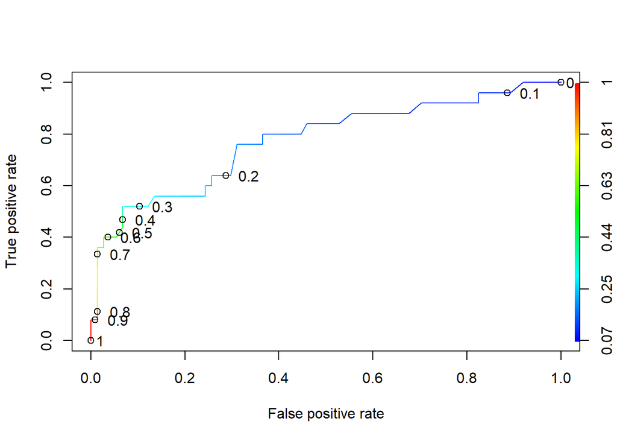

```r
plot(
  ROCR_performance,
  colorize=TRUE,
  print.cutoffs.at=seq(0, 1, 0.1),
  text.adj=c(-0.6, 0.5)
)
```

```r
auc <- performance(ROCR_prediction, 'auc')@y.values
as.numeric(auc)
```

```
## [1] 0.7745946
```

```r
predict_test <- predict(quality_log, type='response', newdata=quality_test)
predict_test
```

```
##          5          7          9         10         12         25         30
## 0.29798887 0.12866111 0.11019695 0.07631334 0.14603309 0.19464371 0.38610001
##         31         32         33         37         41         42         45
## 0.07713767 0.74065581 0.10401409 0.12931480 0.19555741 0.12931480 0.17100226
##         47         49         52         53         66         71         84
## 0.53210006 0.07713767 0.41418219 0.23722970 0.35593066 0.18296035 0.95253087
##         94        104        108        110        111        114        118
## 0.19555741 0.36143723 0.19842376 0.38487933 0.35459795 0.60137213 0.24912944
##        121        124        127        131
## 0.13815174 0.22269138 0.11851083 0.35193932
```

```r
table(quality_test$PoorCare, predict_test >= 0.3)
```

```
##
##     FALSE TRUE
##   0    19    5
##   1     2    6
```

```r
ROCR_prediction_test <- prediction(predict_test, quality_test$PoorCare)
auc <- performance(ROCR_prediction_test, 'auc')@y.values
as.numeric(auc)
```

```
## [1] 0.7994792
```

```r
polling_df <- read.csv('data/PollingData.csv')
str(polling_df)
```

```
## 'data.frame':    145 obs. of  7 variables:
##  $ State     : chr  "Alabama" "Alabama" "Alaska" "Alaska" ...
##  $ Year      : int  2004 2008 2004 2008 2004 2008 2012 2004 2008 2012 ...
##  $ Rasmussen : int  11 21 NA 16 5 5 8 7 10 NA ...
##  $ SurveyUSA : int  18 25 NA NA 15 NA NA 5 NA NA ...
##  $ DiffCount : int  5 5 1 6 8 9 4 8 5 2 ...
##  $ PropR     : num  1 1 1 1 1 ...
##  $ Republican: int  1 1 1 1 1 1 1 1 1 1 ...
```

```r
table(polling_df$Year)
```

```
##
## 2004 2008 2012
##   50   50   45
```

```r
summary(polling_df)
```

```
##     State                Year        Rasmussen          SurveyUSA
##  Length:145         Min.   :2004   Min.   :-41.0000   Min.   :-33.0000
##  Class :character   1st Qu.:2004   1st Qu.: -8.0000   1st Qu.:-11.7500
##  Mode  :character   Median :2008   Median :  1.0000   Median : -2.0000
##                     Mean   :2008   Mean   :  0.0404   Mean   : -0.8243
##                     3rd Qu.:2012   3rd Qu.:  8.5000   3rd Qu.:  8.0000
##                     Max.   :2012   Max.   : 39.0000   Max.   : 30.0000
##                                    NA's   :46         NA's   :71
##    DiffCount           PropR          Republican
##  Min.   :-19.000   Min.   :0.0000   Min.   :0.0000
##  1st Qu.: -6.000   1st Qu.:0.0000   1st Qu.:0.0000
##  Median :  1.000   Median :0.6250   Median :1.0000
##  Mean   : -1.269   Mean   :0.5259   Mean   :0.5103
##  3rd Qu.:  4.000   3rd Qu.:1.0000   3rd Qu.:1.0000
##  Max.   : 11.000   Max.   :1.0000   Max.   :1.0000
##
```

```r
library('mice')
```

```r
sample_polling <- polling_df[c(3:7)]
sample_polling
```

| Rasmussen | SurveyUSA | DiffCount | PropR | Republican |
| --- | --- | --- | --- | --- |
| 11 | 18 | 5 | 1.00000000 | 1 |
| 21 | 25 | 5 | 1.00000000 | 1 |
| NA | NA | 1 | 1.00000000 | 1 |
| 16 | NA | 6 | 1.00000000 | 1 |
| 5 | 15 | 8 | 1.00000000 | 1 |
| 5 | NA | 9 | 1.00000000 | 1 |
| 8 | NA | 4 | 0.83333333 | 1 |
| 7 | 5 | 8 | 1.00000000 | 1 |
| 10 | NA | 5 | 1.00000000 | 1 |
| NA | NA | 2 | 1.00000000 | 1 |

[output cut: 135 more lines]

```r
set.seed(144)
```

```r
imputed <- complete(mice(sample_polling, m=6))
polling_df$Rasmussen <- imputed$Rasmussen
polling_df$SurveyUSA <- imputed$SurveyUSA
polling_df
```

| State | Year | Rasmussen | SurveyUSA | DiffCount | PropR | Republican |
| --- | --- | --- | --- | --- | --- | --- |
| Alabama | 2004 | 11 | 18 | 5 | 1.00000000 | 1 |
| Alabama | 2008 | 21 | 25 | 5 | 1.00000000 | 1 |
| Alaska | 2004 | 39 | 21 | 1 | 1.00000000 | 1 |
| Alaska | 2008 | 16 | 16 | 6 | 1.00000000 | 1 |
| Arizona | 2004 | 5 | 15 | 8 | 1.00000000 | 1 |
| Arizona | 2008 | 5 | 5 | 9 | 1.00000000 | 1 |
| Arizona | 2012 | 8 | 7 | 4 | 0.83333333 | 1 |
| Arkansas | 2004 | 7 | 5 | 8 | 1.00000000 | 1 |
| Arkansas | 2008 | 10 | 8 | 5 | 1.00000000 | 1 |
| Arkansas | 2012 | 10 | 8 | 2 | 1.00000000 | 1 |

[output cut: 135 more lines]

```r
summary(polling_df)
```

```
##     State                Year        Rasmussen         SurveyUSA
##  Length:145         Min.   :2004   Min.   :-41.000   Min.   :-33.000
##  Class :character   1st Qu.:2004   1st Qu.:-10.000   1st Qu.:-11.000
##  Mode  :character   Median :2008   Median :  3.000   Median :  1.000
##                     Mean   :2008   Mean   :  2.717   Mean   :  1.655
##                     3rd Qu.:2012   3rd Qu.: 11.000   3rd Qu.: 16.000
##                     Max.   :2012   Max.   : 39.000   Max.   : 30.000
##    DiffCount           PropR          Republican
##  Min.   :-19.000   Min.   :0.0000   Min.   :0.0000
##  1st Qu.: -6.000   1st Qu.:0.0000   1st Qu.:0.0000
##  Median :  1.000   Median :0.6250   Median :1.0000
##  Mean   : -1.269   Mean   :0.5259   Mean   :0.5103
##  3rd Qu.:  4.000   3rd Qu.:1.0000   3rd Qu.:1.0000
##  Max.   : 11.000   Max.   :1.0000   Max.   :1.0000
```

```r
polling_train <- subset(polling_df, Year == 2004 | Year == 2008)
polling_train
```

|  | State | Year | Rasmussen | SurveyUSA | DiffCount | PropR | Republican |
| --- | --- | --- | --- | --- | --- | --- | --- |
| 1 | Alabama | 2004 | 11 | 18 | 5 | 1.00000000 | 1 |
| 2 | Alabama | 2008 | 21 | 25 | 5 | 1.00000000 | 1 |
| 3 | Alaska | 2004 | 39 | 21 | 1 | 1.00000000 | 1 |
| 4 | Alaska | 2008 | 16 | 16 | 6 | 1.00000000 | 1 |
| 5 | Arizona | 2004 | 5 | 15 | 8 | 1.00000000 | 1 |
| 6 | Arizona | 2008 | 5 | 5 | 9 | 1.00000000 | 1 |
| 8 | Arkansas | 2004 | 7 | 5 | 8 | 1.00000000 | 1 |
| 9 | Arkansas | 2008 | 10 | 8 | 5 | 1.00000000 | 1 |
| 11 | California | 2004 | -11 | -11 | -8 | 0.00000000 | 0 |
| 12 | California | 2008 | -27 | -24 | -5 | 0.00000000 | 0 |

[output cut: 90 more lines]

```r
polling_test <- subset(polling_df, Year == 2012)
polling_test
```

|  | State | Year | Rasmussen | SurveyUSA | DiffCount | PropR | Republican |
| --- | --- | --- | --- | --- | --- | --- | --- |
| 7 | Arizona | 2012 | 8 | 7 | 4 | 0.83333333 | 1 |
| 10 | Arkansas | 2012 | 10 | 8 | 2 | 1.00000000 | 1 |
| 13 | California | 2012 | -11 | -14 | -6 | 0.00000000 | 0 |
| 16 | Colorado | 2012 | 3 | -2 | -5 | 0.30769231 | 0 |
| 19 | Connecticut | 2012 | -7 | -13 | -8 | 0.00000000 | 0 |
| 24 | Florida | 2012 | 2 | 0 | 6 | 0.66666667 | 0 |
| 27 | Georgia | 2012 | 8 | 8 | 4 | 1.00000000 | 1 |
| 30 | Hawaii | 2012 | -5 | -19 | -2 | 0.00000000 | 0 |
| 33 | Idaho | 2012 | 19 | 18 | 1 | 1.00000000 | 1 |
| 36 | Illinois | 2012 | -8 | -8 | -5 | 0.00000000 | 0 |

[output cut: 35 more lines]

```r
table(polling_train$Republican)
```

```
##
##  0  1
## 47 53
```

```r
table(sign(polling_train$Rasmussen))
```

```
##
## -1  0  1
## 42  2 56
```

```r
table(polling_train$Republican, sign(polling_train$Rasmussen))
```

```
##
##     -1  0  1
##   0 42  1  4
##   1  0  1 52
```

```r
table(polling_train$Republican, sign(polling_train$Rasmussen))
```

```
##
##     -1  0  1
##   0 42  1  4
##   1  0  1 52
```

```r
cor(polling_train[c(3:7)])
```

```
##            Rasmussen SurveyUSA DiffCount     PropR Republican
## Rasmussen  1.0000000 0.9022207 0.5078495 0.8290504  0.7820578
## SurveyUSA  0.9022207 1.0000000 0.5649894 0.8676054  0.7981508
## DiffCount  0.5078495 0.5649894 1.0000000 0.8273785  0.8092777
## PropR      0.8290504 0.8676054 0.8273785 1.0000000  0.9484204
## Republican 0.7820578 0.7981508 0.8092777 0.9484204  1.0000000
```

```r
polling_model1 <- glm(Republican ~ PropR, family='binomial', data=polling_train)
summary(polling_model1)
```

```
##
## Call:
## glm(formula = Republican ~ PropR, family = "binomial", data = polling_train)
##
## Deviance Residuals:
##      Min        1Q    Median        3Q       Max
## -2.22880  -0.06541   0.10260   0.10260   1.37392
##
## Coefficients:
##             Estimate Std. Error z value Pr(>|z|)
## (Intercept)   -6.146      1.977  -3.108 0.001882 **
## PropR         11.390      3.153   3.613 0.000303 ***
## ---
## Signif. codes:  0 '***' 0.001 '**' 0.01 '*' 0.05 '.' 0.1 ' ' 1
##
## (Dispersion parameter for binomial family taken to be 1)
##
##     Null deviance: 138.269  on 99  degrees of freedom
## Residual deviance:  15.772  on 98  degrees of freedom
## AIC: 19.772
##
## Number of Fisher Scoring iterations: 8
```

Искаме голяма разлика между Null deviance > Residual deviance.

```r
polling_predict <- predict(polling_model1, type='response')
polling_predict
```

```
##           1           2           3           4           5           6
## 0.994750046 0.994750046 0.994750046 0.994750046 0.994750046 0.994750046
##           8           9          11          12          14          15
## 0.994750046 0.994750046 0.002137101 0.002137101 0.994750046 0.002137101
##          17          18          20          21          22          23
## 0.002137101 0.002137101 0.002137101 0.002137101 0.389135666 0.012771623
##          25          26          28          29          31          32
## 0.994750046 0.994750046 0.916572458 0.002137101 0.994750046 0.994750046
##          34          35          37          38          40          41
## 0.002137101 0.002137101 0.994750046 0.725688768 0.809607135 0.002137101
##          43          44          46          47          49          50
## 0.994750046 0.994750046 0.994750046 0.994750046 0.994750046 0.994750046
##          52          53          55          56          58          59
## 0.002137101 0.002137101 0.002137101 0.002137101 0.002137101 0.002137101
##          61          62          64          65          67          68
## 0.002137101 0.009685038 0.016705394 0.002137101 0.994750046 0.994750046
##          70          71          73          74          76          77
## 0.994750046 0.965969194 0.994750046 0.916572458 0.994750046 0.994750046
##          79          80          82          83          85          86
## 0.994750046 0.005995864 0.026212483 0.002137101 0.002137101 0.002137101
##          88          89          91          92          94          95
## 0.725688768 0.002137101 0.002137101 0.002137101 0.994750046 0.087117199
##          97          98         100         101         103         104
## 0.994750046 0.389135666 0.665543447 0.006645669 0.994750046 0.994750046
##         106         107         109         110         112         113
## 0.006645669 0.002137101 0.008815745 0.002137101 0.002137101 0.002137101
##         115         116         118         119         121         122
## 0.994750046 0.994750046 0.994750046 0.994750046 0.994750046 0.994750046
##         124         125         127         128         130         131
## 0.994750046 0.994750046 0.994750046 0.994750046 0.002137101 0.002137101
##         132         133         135         136         138         139
## 0.994750046 0.002137101 0.002137101 0.002137101 0.994750046 0.994750046
##         141         142         144         145
## 0.482191137 0.002137101 0.994750046 0.994750046
```

```r
table(polling_train$Republican, polling_predict >= 0.5)
```

```
##
##     FALSE TRUE
##   0    45    2
##   1     2   51
```

```r
polling_model2 <- glm(Republican ~ SurveyUSA + DiffCount, family='binomial', data=polling_train)
summary(polling_model2)
```

```
##
## Call:
## glm(formula = Republican ~ SurveyUSA + DiffCount, family = "binomial",
##     data = polling_train)
##
## Deviance Residuals:
##      Min        1Q    Median        3Q       Max
## -2.59187  -0.02822   0.02821   0.15029   1.41032
##
## Coefficients:
##             Estimate Std. Error z value Pr(>|z|)
## (Intercept) -0.66104    0.81858  -0.808   0.4194
## SurveyUSA    0.12842    0.06861   1.872   0.0612 .
## DiffCount    0.83646    0.36765   2.275   0.0229 *
## ---
## Signif. codes:  0 '***' 0.001 '**' 0.01 '*' 0.05 '.' 0.1 ' ' 1
##
## (Dispersion parameter for binomial family taken to be 1)
##
##     Null deviance: 138.269  on 99  degrees of freedom
## Residual deviance:  17.813  on 97  degrees of freedom
## AIC: 23.813
##
## Number of Fisher Scoring iterations: 8
```

```r
polling_predict <- predict(polling_model2, type='response')
polling_predict
```

```
##            1            2            3            4            5            6
## 9.970790e-01 9.988091e-01 9.464603e-01 9.983618e-01 9.996499e-01 9.994523e-01
##            8            9           11           12           14           15
## 9.987367e-01 9.895294e-01 1.560150e-04 3.612734e-04 9.992920e-01 4.470282e-07
##           17           18           20           21           22           23
## 7.845540e-03 2.325096e-03 3.794508e-02 3.858831e-04 3.699059e-01 6.653689e-06
##           25           26           28           29           31           32
## 9.855981e-01 9.995763e-01 9.652262e-01 2.458563e-02 8.779698e-01 9.672641e-01
##           34           35           37           38           40           41
## 1.684776e-03 1.672166e-04 9.864588e-01 7.333884e-01 9.583536e-01 9.334685e-05
##           43           44           46           47           49           50
## 9.918542e-01 9.760786e-01 9.894938e-01 9.962268e-01 9.962268e-01 9.813963e-01
##           52           53           55           56           58           59
## 1.220581e-03 4.971264e-04 8.306456e-04 8.344238e-02 2.033141e-02 2.045451e-03
##           61           62           64           65           67           68
## 1.792501e-02 3.544807e-05 1.299198e-03 2.882656e-06 9.825037e-01 9.607778e-01
##           70           71           73           74           76           77
## 9.987367e-01 9.361243e-01 9.894938e-01 9.498676e-01 9.855494e-01 9.464603e-01
##           79           80           82           83           85           86
## 9.996274e-01 1.660753e-04 2.474678e-03 1.031825e-06 1.372148e-04 7.686044e-05
##           88           89           91           92           94           95
## 6.517211e-01 1.387610e-03 3.382326e-04 1.137581e-04 9.980178e-01 8.880867e-03
##           97           98          100          101          103          104
## 9.652262e-01 4.952682e-01 8.914068e-01 6.152120e-07 9.985540e-01 9.836016e-01
##          106          107          109          110          112          113
## 4.357451e-04 2.419717e-05 1.985523e-05 2.036090e-08 1.792501e-02 3.218967e-03
##          115          116          118          119          121          122
## 9.932833e-01 9.895294e-01 9.761584e-01 9.932833e-01 9.994504e-01 9.895294e-01
##          124          125          127          128          130          131
## 9.789007e-01 9.895294e-01 9.397611e-01 9.936877e-01 2.033141e-02 1.397135e-03
##          132          133          135          136          138          139
## 9.826211e-01 8.931728e-08 7.195725e-05 4.372395e-04 9.987324e-01 9.998831e-01
##          141          142          144          145
## 5.437428e-01 2.892547e-06 9.464603e-01 9.894938e-01
```

```r
table(polling_train$Republican, polling_predict >= 0.3)
```

```
##
##     FALSE TRUE
##   0    44    3
##   1     0   53
```